# Human Activity Recognition

## Background

Using devices such as Jawbone Up, Nike FuelBand, and Fitbit it is now possible to collect a large amount of data about personal activity relatively inexpensively. These type of devices are part of the quantified self movement – a group of enthusiasts who take measurements about themselves regularly to improve their health, to find patterns in their behavior, or because they are tech geeks. One thing that people regularly do is quantify how much of a particular activity they do, but they rarely quantify how well they do it.

this project we will use data from accelerometers on the belt, forearm, arm, and dumbell of 6 participants. They were asked to perform barbell lifts correctly and incorrectly in 5 different ways. More information is available from the website here: http://groupware.les.inf.puc-rio.br/har (see the section on the Weight Lifting Exercise Dataset).

## Loading and Preprocessing data

#### Loading the data.

The training data for this project are available here:

https://d396qusza40orc.cloudfront.net/predmachlearn/pml-training.csv

The test data are available here:

https://d396qusza40orc.cloudfront.net/predmachlearn/pml-testing.csv

```r
library(ggplot2)
library(caret)
library(randomForest)
library(reshape2)
```

```r
training <- read.csv('pml-training.csv', na.strings=c('NA', '', '#DIV/0!'))
testing <- read.csv('pml-testing.csv', na.strings=c('NA', '', '#DIV/0!'))
```

#### Preprocessing

remove info features (1 to 7 columns) and features which has NA value.

```r
infoList <- 1:7
naList <- which(apply(training, 2, function(x) sum(is.na(x))) > 0)
excludeList <- c(infoList, naList)
training <- training[, -excludeList]
testing <- testing[, -excludeList]
```

split the training data to subTrain and subTest for cross-validation.

```r
set.seed(9527)
inTrain <- createDataPartition(training$classe, p=.7, list=FALSE)
subTrain <- training[inTrain,]
subTest <- training[-inTrain,]
```

look up the features correlation.

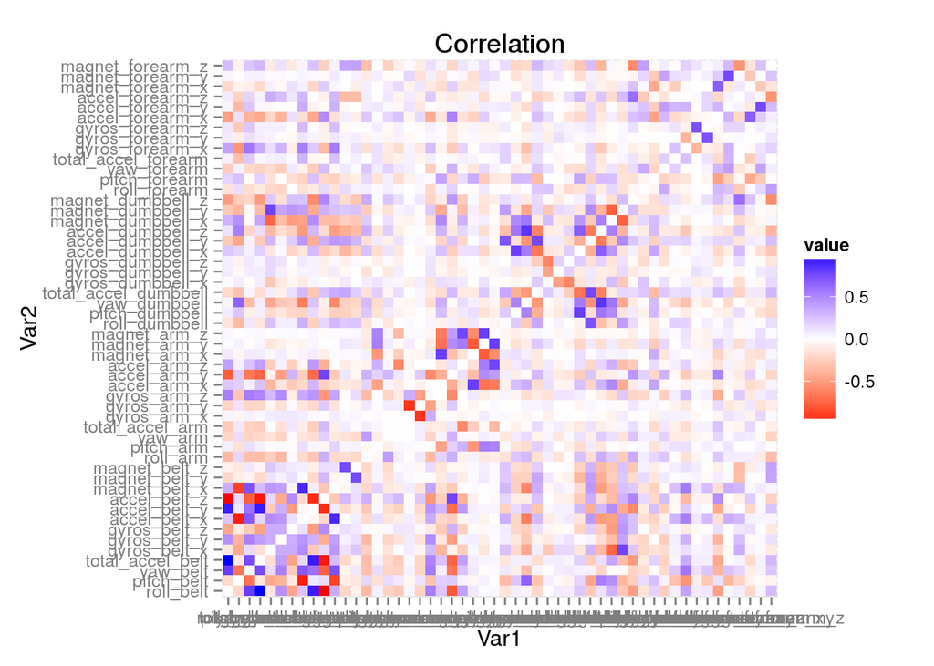

```r
correl <- cor(subTrain[,-dim(subTrain)[2]])
diag(correl) <- 0
g <- ggplot(melt(correl), aes(x=Var1, y=Var2, fill=value))
g <- g + labs(title='Correlation')
g <- g + geom_raster()
g <- g + scale_fill_gradientn(colours=c('red', 'white', 'blue'))
g
```

## Fitting and Validation

fit model with randomForest

```r
set.seed(9527)
fit <- randomForest(classe ~ ., data=subTrain)
fit
```

```
##
## Call:
##  randomForest(formula = classe ~ ., data = subTrain)
##                Type of random forest: classification
##                      Number of trees: 500
## No. of variables tried at each split: 7
##
##         OOB estimate of  error rate: 0.61%
## Confusion matrix:
##      A    B    C    D    E class.error
## A 3902    4    0    0    0 0.001024066
## B   14 2638    6    0    0 0.007524454
## C    0   18 2373    5    0 0.009599332
## D    0    0   24 2226    2 0.011545293
## E    0    0    1   10 2514 0.004356436
```

the OOB estimate of error rate is 0.61%, it’s small enough.

cross-validation

```r
confuMatrix <- confusionMatrix(predict(fit, subTest), subTest$classe)
confuMatrix
```

```
## Confusion Matrix and Statistics
##
##           Reference
## Prediction    A    B    C    D    E
##          A 1673    4    0    0    0
##          B    0 1135    6    0    0
##          C    0    0 1019    6    0
##          D    0    0    1  958    6
##          E    1    0    0    0 1076
##
## Overall Statistics
##
##                Accuracy : 0.9959
##                  95% CI : (0.9939, 0.9974)
##     No Information Rate : 0.2845
##     P-Value [Acc > NIR] : < 2.2e-16
##
##                   Kappa : 0.9948
##  Mcnemar's Test P-Value : NA
##
## Statistics by Class:
##
##                      Class: A Class: B Class: C Class: D Class: E
## Sensitivity            0.9994   0.9965   0.9932   0.9938   0.9945
## Specificity            0.9991   0.9987   0.9988   0.9986   0.9998
## Pos Pred Value         0.9976   0.9947   0.9941   0.9927   0.9991
## Neg Pred Value         0.9998   0.9992   0.9986   0.9988   0.9988
## Prevalence             0.2845   0.1935   0.1743   0.1638   0.1839
## Detection Rate         0.2843   0.1929   0.1732   0.1628   0.1828
## Detection Prevalence   0.2850   0.1939   0.1742   0.1640   0.1830
## Balanced Accuracy      0.9992   0.9976   0.9960   0.9962   0.9971
```

the estimate out of sample error is 0.41% , all of class’s sensitivity is greater than 99% .

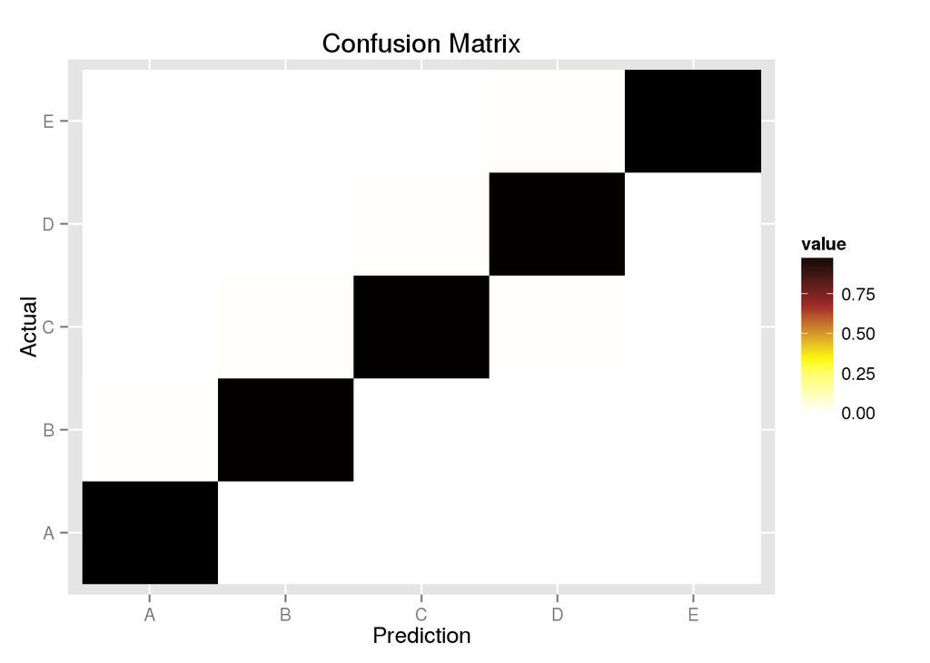

```r
cm <- apply(confuMatrix$table, 1, function(x) x/sum(x))
names(dimnames(cm))[1] <- 'Actual'
cm <- melt(cm)
g <- ggplot(cm, aes(x=Prediction, y=Actual, fill=value))
g <- g + labs(title='Confusion Matrix')
g <- g + geom_raster()
g <- g + scale_fill_gradientn(colours=c('white', 'yellow', 'brown', 'black'))
g
```

## Prediction

apply the machine learning algorithm to the testing data set.

```r
pred <- predict(fit, testing)
pred
```

```
##  1  2  3  4  5  6  7  8  9 10 11 12 13 14 15 16 17 18 19 20
##  B  A  B  A  A  E  D  B  A  A  B  C  B  A  E  E  A  B  B  B
## Levels: A B C D E
```

```r
pml_write_files = function(x){
      n = length(x)
  for(i in 1:n){
          filename = paste0("problem_id_",i,".txt")
      write.table(x[i],file=filename,quote=FALSE,row.names=FALSE,col.names=FALSE)
        }
}
pml_write_files(pred)
```